# Project: Ford Gobike Exploration

# Introduction

public bike share (PBS) scheme ، It is the one of the services that allows the shared use of bicycles for a low price or for free ، One of the advantages of this system is that it allows people to borrow a bike from one dock and return it to another dock ، The Docks are equipped with a system to lock and on lock the bicycles by computer control ، The person enters the payment method ، Then the computer opens the lock to return the bike .

In this project we will perform an exploratory analysis of data provided by Ford GoBike, a bike-share system provider.

# Wrangling

Ford GoBike It is a local bike-sharing system in San Francisco , In this dataset we have information about , individual bicycle rides made in a bike-sharing system and, the dataset which will be explored from june 2017 to december 2018.

```python
import numpy as np
import pandas as pd
import matplotlib.pyplot as plt
import seaborn as sb
from pandas import Series, DataFrame
import requests
import os
import csv
%matplotlib inline
```

```python
# in this step we download 2017 data
file = '2017_fordgobike.csv'
if not os.path.exists(file):
    url = 'https://s3.amazonaws.com/fordgobike-data/2017-fordgobike-tripdata.csv'
    r = requests.get(url)

    if r.status_code == 200:
        with open(file, 'wb') as outfile:
            outfile.write(r.content)
    else:
        print(url,' not found')
```

```python
# in this step we download 2017 data

for i in range(12):
    month = '%02d' % (i+1)
    file = '2018_' + month + '_fordgobike.zip'
    if not os.path.exists(file):
        url = 'https://s3.amazonaws.com/fordgobike-data/2018' + month + '-fordgobike-tripdata.csv.zip'
        r = requests.get(url)

        if r.status_code == 200:
            with open(file, 'wb') as outfile:
                outfile.write(r.content)
        else:
            print(url,' not found')
```

```python
# in this step we loading 2017 data
data_2017 = pd.read_csv('2017_fordgobike.csv')
```

```python
data_2017.head()
```

|  | duration_sec | start_time | end_time | start_station_id | start_station_name | start_station_latitude | start_station_longitude | end_station_id | end_station_name | end_station_latitude | end_station_longitude | bike_id | user_type | member_birth_year | member_gender |
| --- | --- | --- | --- | --- | --- | --- | --- | --- | --- | --- | --- | --- | --- | --- | --- |
| 0 | 80110 | 2017-12-31 16:57:39.6540 | 2018-01-01 15:12:50.2450 | 74 | Laguna St at Hayes St | 37.776435 | -122.426244 | 43 | San Francisco Public Library (Grove St at Hyde... | 37.778768 | -122.415929 | 96 | Customer | 1987.0 | Male |
| 1 | 78800 | 2017-12-31 15:56:34.8420 | 2018-01-01 13:49:55.6170 | 284 | Yerba Buena Center for the Arts (Howard St at ... | 37.784872 | -122.400876 | 96 | Dolores St at 15th St | 37.766210 | -122.426614 | 88 | Customer | 1965.0 | Female |
| 2 | 45768 | 2017-12-31 22:45:48.4110 | 2018-01-01 11:28:36.8830 | 245 | Downtown Berkeley BART | 37.870348 | -122.267764 | 245 | Downtown Berkeley BART | 37.870348 | -122.267764 | 1094 | Customer | NaN | NaN |
| 3 | 62172 | 2017-12-31 17:31:10.6360 | 2018-01-01 10:47:23.5310 | 60 | 8th St at Ringold St | 37.774520 | -122.409449 | 5 | Powell St BART Station (Market St at 5th St) | 37.783899 | -122.408445 | 2831 | Customer | NaN | NaN |
| 4 | 43603 | 2017-12-31 14:23:14.0010 | 2018-01-01 02:29:57.5710 | 239 | Bancroft Way at Telegraph Ave | 37.868813 | -122.258764 | 247 | Fulton St at Bancroft Way | 37.867789 | -122.265896 | 3167 | Subscriber | 1997.0 | Female |

```python
# in this step we get general info Data_2017
data_2017.info()
```

```
<class 'pandas.core.frame.DataFrame'>
RangeIndex: 519700 entries, 0 to 519699
Data columns (total 15 columns):
 #   Column                   Non-Null Count   Dtype
---  ------                   --------------   -----
 0   duration_sec             519700 non-null  int64
 1   start_time               519700 non-null  object
 2   end_time                 519700 non-null  object
 3   start_station_id         519700 non-null  int64
 4   start_station_name       519700 non-null  object
 5   start_station_latitude   519700 non-null  float64
 6   start_station_longitude  519700 non-null  float64
 7   end_station_id           519700 non-null  int64
 8   end_station_name         519700 non-null  object
 9   end_station_latitude     519700 non-null  float64
 10  end_station_longitude    519700 non-null  float64
 11  bike_id                  519700 non-null  int64
 12  user_type                519700 non-null  object
 13  member_birth_year        453159 non-null  float64
 14  member_gender            453238 non-null  object
dtypes: float64(5), int64(4), object(6)
memory usage: 59.5+ MB
```

```python
# in this step we Get overview 2017 Data
data_2017.shape
```

```
(519700, 15)
```

```python
# in this step we loading 2018 data to a dictionary It has data every month
dictionary18 = {}
for i in range(12):
    month = '%02d' % (i+1)
    file = '2018_' + month + '_fordgobike.zip'
    if os.path.exists(file):
        dictionary18[month] = pd.read_csv(file)

dictionary18['01'].head()
```

|  | duration_sec | start_time | end_time | start_station_id | start_station_name | start_station_latitude | start_station_longitude | end_station_id | end_station_name | end_station_latitude | end_station_longitude | bike_id | user_type | member_birth_year | member_gender | bike_share_for_all_trip |
| --- | --- | --- | --- | --- | --- | --- | --- | --- | --- | --- | --- | --- | --- | --- | --- | --- |
| 0 | 75284 | 2018-01-31 22:52:35.2390 | 2018-02-01 19:47:19.8240 | 120 | Mission Dolores Park | 37.761420 | -122.426435 | 285 | Webster St at O'Farrell St | 37.783521 | -122.431158 | 2765 | Subscriber | 1986.0 | Male | No |
| 1 | 85422 | 2018-01-31 16:13:34.3510 | 2018-02-01 15:57:17.3100 | 15 | San Francisco Ferry Building (Harry Bridges Pl... | 37.795392 | -122.394203 | 15 | San Francisco Ferry Building (Harry Bridges Pl... | 37.795392 | -122.394203 | 2815 | Customer | NaN | NaN | No |
| 2 | 71576 | 2018-01-31 14:23:55.8890 | 2018-02-01 10:16:52.1160 | 304 | Jackson St at 5th St | 37.348759 | -121.894798 | 296 | 5th St at Virginia St | 37.325998 | -121.877120 | 3039 | Customer | 1996.0 | Male | No |
| 3 | 61076 | 2018-01-31 14:53:23.5620 | 2018-02-01 07:51:20.5000 | 75 | Market St at Franklin St | 37.773793 | -122.421239 | 47 | 4th St at Harrison St | 37.780955 | -122.399749 | 321 | Customer | NaN | NaN | No |
| 4 | 39966 | 2018-01-31 19:52:24.6670 | 2018-02-01 06:58:31.0530 | 74 | Laguna St at Hayes St | 37.776435 | -122.426244 | 19 | Post St at Kearny St | 37.788975 | -122.403452 | 617 | Subscriber | 1991.0 | Male | No |

```python
# in this step we get general info 2018 data
dictionary18['01'].info()
```

```
<class 'pandas.core.frame.DataFrame'>
RangeIndex: 94802 entries, 0 to 94801
Data columns (total 16 columns):
 #   Column                   Non-Null Count  Dtype
---  ------                   --------------  -----
 0   duration_sec             94802 non-null  int64
 1   start_time               94802 non-null  object
 2   end_time                 94802 non-null  object
 3   start_station_id         94802 non-null  int64
 4   start_station_name       94802 non-null  object
 5   start_station_latitude   94802 non-null  float64
 6   start_station_longitude  94802 non-null  float64
 7   end_station_id           94802 non-null  int64
 8   end_station_name         94802 non-null  object
 9   end_station_latitude     94802 non-null  float64
 10  end_station_longitude    94802 non-null  float64
 11  bike_id                  94802 non-null  int64
 12  user_type                94802 non-null  object
 13  member_birth_year        86963 non-null  float64
 14  member_gender            87001 non-null  object
 15  bike_share_for_all_trip  94802 non-null  object
dtypes: float64(5), int64(4), object(7)
memory usage: 11.6+ MB
```

```python
# in this step we Get overview 2018 Data
dictionary18['01'].shape
```

```
(94802, 16)
```

```python
# collecting monthly dataframes to one dataset
list18 = []
for i in range(12):
    month = '%02d' % (i+1)
    file = '2018_' + month + '_fordgobike.zip'
    if os.path.exists(file):
        list18.append(dictionary18[month])

data_2018 = pd.concat(list18, ignore_index = True)
```

```python
data_2018.info()
```

```
<class 'pandas.core.frame.DataFrame'>
RangeIndex: 1863721 entries, 0 to 1863720
Data columns (total 16 columns):
 #   Column                   Dtype
---  ------                   -----
 0   duration_sec             int64
 1   start_time               object
 2   end_time                 object
 3   start_station_id         float64
 4   start_station_name       object
 5   start_station_latitude   float64
 6   start_station_longitude  float64
 7   end_station_id           float64
 8   end_station_name         object
 9   end_station_latitude     float64
 10  end_station_longitude    float64
 11  bike_id                  int64
 12  user_type                object
 13  member_birth_year        float64
 14  member_gender            object
 15  bike_share_for_all_trip  object
dtypes: float64(7), int64(2), object(7)
memory usage: 227.5+ MB
```

```python
data_2018.columns
```

```
Index(['duration_sec', 'start_time', 'end_time', 'start_station_id',
       'start_station_name', 'start_station_latitude',
       'start_station_longitude', 'end_station_id', 'end_station_name',
       'end_station_latitude', 'end_station_longitude', 'bike_id', 'user_type',
       'member_birth_year', 'member_gender', 'bike_share_for_all_trip'],
      dtype='object')
```

```python
# we go to reomve "bike_share_for_all_trip" column
data_2018 = data_2018.drop(['bike_share_for_all_trip'], axis = 1)
```

```python
#concat the df 17 and the df 18
df1718 = pd.concat([data_2017, data_2018], ignore_index = True)
```

```python
df1718.head()
```

|  | duration_sec | start_time | end_time | start_station_id | start_station_name | start_station_latitude | start_station_longitude | end_station_id | end_station_name | end_station_latitude | end_station_longitude | bike_id | user_type | member_birth_year | member_gender |
| --- | --- | --- | --- | --- | --- | --- | --- | --- | --- | --- | --- | --- | --- | --- | --- |
| 0 | 80110 | 2017-12-31 16:57:39.6540 | 2018-01-01 15:12:50.2450 | 74.0 | Laguna St at Hayes St | 37.776435 | -122.426244 | 43.0 | San Francisco Public Library (Grove St at Hyde... | 37.778768 | -122.415929 | 96 | Customer | 1987.0 | Male |
| 1 | 78800 | 2017-12-31 15:56:34.8420 | 2018-01-01 13:49:55.6170 | 284.0 | Yerba Buena Center for the Arts (Howard St at ... | 37.784872 | -122.400876 | 96.0 | Dolores St at 15th St | 37.766210 | -122.426614 | 88 | Customer | 1965.0 | Female |
| 2 | 45768 | 2017-12-31 22:45:48.4110 | 2018-01-01 11:28:36.8830 | 245.0 | Downtown Berkeley BART | 37.870348 | -122.267764 | 245.0 | Downtown Berkeley BART | 37.870348 | -122.267764 | 1094 | Customer | NaN | NaN |
| 3 | 62172 | 2017-12-31 17:31:10.6360 | 2018-01-01 10:47:23.5310 | 60.0 | 8th St at Ringold St | 37.774520 | -122.409449 | 5.0 | Powell St BART Station (Market St at 5th St) | 37.783899 | -122.408445 | 2831 | Customer | NaN | NaN |
| 4 | 43603 | 2017-12-31 14:23:14.0010 | 2018-01-01 02:29:57.5710 | 239.0 | Bancroft Way at Telegraph Ave | 37.868813 | -122.258764 | 247.0 | Fulton St at Bancroft Way | 37.867789 | -122.265896 | 3167 | Subscriber | 1997.0 | Female |

```python
df1718.info()
```

```
<class 'pandas.core.frame.DataFrame'>
RangeIndex: 2383421 entries, 0 to 2383420
Data columns (total 15 columns):
 #   Column                   Dtype
---  ------                   -----
 0   duration_sec             int64
 1   start_time               object
 2   end_time                 object
 3   start_station_id         float64
 4   start_station_name       object
 5   start_station_latitude   float64
 6   start_station_longitude  float64
 7   end_station_id           float64
 8   end_station_name         object
 9   end_station_latitude     float64
 10  end_station_longitude    float64
 11  bike_id                  int64
 12  user_type                object
 13  member_birth_year        float64
 14  member_gender            object
dtypes: float64(7), int64(2), object(6)
memory usage: 272.8+ MB
```

```python
# check the early ride date in the dataset
df1718['start_time'].min()
```

```
'2017-06-28 09:47:36.3470'
```

```python
# check the last ride date in the dataset
df1718['start_time'].max()
```

```
'2018-12-31 23:59:12.0970'
```

```python
pd.set_option('display.float_format', lambda x: '%.2f' % x)
df1718.describe()
```

|  | duration_sec | start_station_id | start_station_latitude | start_station_longitude | end_station_id | end_station_latitude | end_station_longitude | bike_id | member_birth_year |
| --- | --- | --- | --- | --- | --- | --- | --- | --- | --- |
| count | 2383421.00 | 2371650.00 | 2383421.00 | 2383421.00 | 2371650.00 | 2383421.00 | 2383421.00 | 2383421.00 | 2206162.00 |
| mean | 910.01 | 114.28 | 37.77 | -122.35 | 112.48 | 37.77 | -122.35 | 2160.72 | 1982.54 |
| std | 2643.87 | 97.97 | 0.10 | 0.15 | 97.85 | 0.10 | 0.15 | 1252.54 | 10.51 |
| min | 61.00 | 3.00 | 37.26 | -122.47 | 3.00 | 37.26 | -122.47 | 10.00 | 1881.00 |
| 25% | 357.00 | 30.00 | 37.77 | -122.41 | 29.00 | 37.77 | -122.41 | 1119.00 | 1977.00 |
| 50% | 564.00 | 81.00 | 37.78 | -122.40 | 81.00 | 37.78 | -122.40 | 2173.00 | 1985.00 |
| 75% | 885.00 | 181.00 | 37.80 | -122.29 | 180.00 | 37.80 | -122.29 | 3116.00 | 1990.00 |
| max | 86369.00 | 381.00 | 45.51 | -73.57 | 381.00 | 45.51 | -73.57 | 6234.00 | 2000.00 |

```python
# check gender value counts
df1718['member_gender'].value_counts()
```

```
Male      1636403
Female     536809
Other       33380
Name: member_gender, dtype: int64
```

```python
# check Calculate the value of gender
df1718['member_gender'].value_counts()
```

```
Male      1636403
Female     536809
Other       33380
Name: member_gender, dtype: int64
```

```python
# check Calculate the value user type
df1718['user_type'].value_counts()
```

```
Subscriber    1992784
Customer       390637
Name: user_type, dtype: int64
```

#### converting non-null values 'start_station_id' and 'end_station_id' to strings and

#### converting "bike_id" from int to string

```python
#  in this step we converting non-null values to strings
df1718['start_station_id'] =df1718['start_station_id'].where(df1718['start_station_id'].isnull(), df1718['start_station_id'].map(lambda x: '{:.0f}'.format(x)).astype(str))
df1718['end_station_id'] = df1718['end_station_id'].where(df1718['end_station_id'].isnull(), df1718['end_station_id'].map(lambda x: '{:.0f}'.format(x)).astype(str))
```

```python
# in this step we converting "bike_id" from int to string
df1718['bike_id'] = df1718['bike_id'].astype(str)
```

```python
df1718.dtypes
```

```
duration_sec                 int64
start_time                  object
end_time                    object
start_station_id            object
start_station_name          object
start_station_latitude     float64
start_station_longitude    float64
end_station_id              object
end_station_name            object
end_station_latitude       float64
end_station_longitude      float64
bike_id                     object
user_type                   object
member_birth_year          float64
member_gender               object
dtype: object
```

converting 'member_birth_year' from float64 to integer chek from converting

```python
# converting
df1718['member_birth_year'] = df1718['member_birth_year'].fillna(0).astype(int)
```

```python
# chek
df1718.dtypes
```

```
duration_sec                 int64
start_time                  object
end_time                    object
start_station_id            object
start_station_name          object
start_station_latitude     float64
start_station_longitude    float64
end_station_id              object
end_station_name            object
end_station_latitude       float64
end_station_longitude      float64
bike_id                     object
user_type                   object
member_birth_year            int64
member_gender               object
dtype: object
```

converting 'start_time' and 'end_time' to datetime

```python
# converting
df1718['start_time'] = pd.to_datetime(df1718['start_time'])
df1718['end_time'] = pd.to_datetime(df1718['end_time'])
```

```python
df1718.dtypes
```

```
duration_sec                        int64
start_time                 datetime64[ns]
end_time                   datetime64[ns]
start_station_id                   object
start_station_name                 object
start_station_latitude            float64
start_station_longitude           float64
end_station_id                     object
end_station_name                   object
end_station_latitude              float64
end_station_longitude             float64
bike_id                            object
user_type                          object
member_birth_year                   int64
member_gender                      object
dtype: object
```

We can estimate a simple age by way of his year of birth and time of departure. Represent null ages due to missing birth year by 0.

```python
df1718.loc[df1718['member_birth_year'] == 0, 'Age'] = 0
df1718.loc[df1718['member_birth_year'] > 0, 'Age'] = df1718['start_time'].dt.year - df1718['member_birth_year']
df1718['Age'] = df1718['Age'].astype(int)
```

```python
df1718.dtypes
```

```
duration_sec                        int64
start_time                 datetime64[ns]
end_time                   datetime64[ns]
start_station_id                   object
start_station_name                 object
start_station_latitude            float64
start_station_longitude           float64
end_station_id                     object
end_station_name                   object
end_station_latitude              float64
end_station_longitude             float64
bike_id                            object
user_type                          object
member_birth_year                   int64
member_gender                      object
Age                                 int64
dtype: object
```

```python
df1718['Age'].value_counts().head(3)
```

```
0     177259
30    125329
29    108440
Name: Age, dtype: int64
```

```python
# Create new column 'duration_mins' & converting seconds to minutes
df1718['duration_mins'] = df1718['duration_sec']/60
```

```python
df1718.sample(3)
```

|  | duration_sec | start_time | end_time | start_station_id | start_station_name | start_station_latitude | start_station_longitude | end_station_id | end_station_name | end_station_latitude | end_station_longitude | bike_id | user_type | member_birth_year | member_gender | Age | duration_mins |
| --- | --- | --- | --- | --- | --- | --- | --- | --- | --- | --- | --- | --- | --- | --- | --- | --- | --- |
| 693734 | 393 | 2018-02-07 17:19:47.988 | 2018-02-07 17:26:21.015 | 20 | Mechanics Monument Plaza (Market St at Bush St) | 37.79 | -122.40 | 5 | Powell St BART Station (Market St at 5th St) | 37.78 | -122.41 | 136 | Subscriber | 1997 | Male | 21 | 6.55 |
| 1698168 | 856 | 2018-08-06 14:17:02.943 | 2018-08-06 14:31:19.653 | 231 | 14th St at Filbert St | 37.81 | -122.28 | 182 | 19th Street BART Station | 37.81 | -122.27 | 1637 | Subscriber | 1982 | Female | 36 | 14.27 |
| 208800 | 327 | 2017-10-24 17:46:16.932 | 2017-10-24 17:51:44.828 | 48 | 2nd St at S Park St | 37.78 | -122.39 | 321 | 5th at Folsom | 37.78 | -122.40 | 2276 | Customer | 1991 | Male | 26 | 5.45 |

```python
df1718.to_csv("fordgobike_combined.csv", header=True, index=False)
```

```python
df1718.shape
```

```
(2383421, 17)
```

```python
df1718.info()
```

```
<class 'pandas.core.frame.DataFrame'>
RangeIndex: 2383421 entries, 0 to 2383420
Data columns (total 17 columns):
 #   Column                   Dtype
---  ------                   -----
 0   duration_sec             int64
 1   start_time               datetime64[ns]
 2   end_time                 datetime64[ns]
 3   start_station_id         object
 4   start_station_name       object
 5   start_station_latitude   float64
 6   start_station_longitude  float64
 7   end_station_id           object
 8   end_station_name         object
 9   end_station_latitude     float64
 10  end_station_longitude    float64
 11  bike_id                  object
 12  user_type                object
 13  member_birth_year        int64
 14  member_gender            object
 15  Age                      int64
 16  duration_mins            float64
dtypes: datetime64[ns](2), float64(5), int64(3), object(7)
memory usage: 309.1+ MB
```

## What is/are the main feature(s) of interest in your dataset?

Total number of rounds and duration

Duration per trip.

What kind of users are using the FordGoBike service more and less.

## What features in the dataset do you think will help support your investigation into your feature(s) of interest?

Some information for data year of birth and gender, can give us insight into the number of users.

```python
df1718_copy = df1718.copy()
```

# Exploration

```python
# default visualization of parameters.
sb.set_style('darkgrid')
```

```python
# Distribution of gender
(df1718_copy.member_gender.value_counts(sort=True, normalize=True)*100)
```

```
Male     74.16
Female   24.33
Other     1.51
Name: member_gender, dtype: float64
```

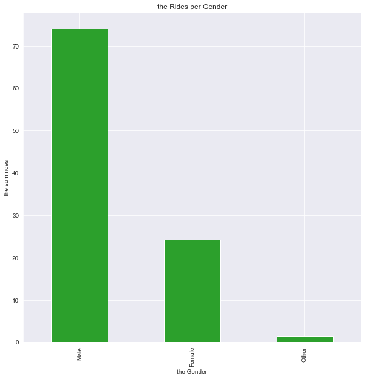

```python
plt.figure(figsize=[10, 10])
(df1718_copy.member_gender.value_counts(sort=True, normalize=True)*100).plot.bar(color = sb.color_palette()[2]);
plt.title("the Rides per Gender")
plt.ylabel("the sum rides")
plt.xlabel("the Gender");
```

#### The result is that males make more trips

```python
#Distribution of users
(df1718_copy.user_type.value_counts(sort=True, normalize=True)*100)
```

```
Subscriber   83.61
Customer     16.39
Name: user_type, dtype: float64
```

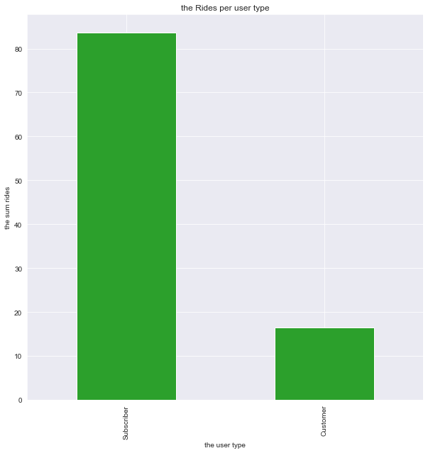

```python
plt.figure(figsize=[10, 10])
(df1718_copy.user_type.value_counts(sort=True, normalize=True)*100).plot.bar(color = sb.color_palette()[2])
plt.title("the Rides per user type")
plt.ylabel("the sum rides")
plt.xlabel("the user type");
```

#### th subscribers type have most rides

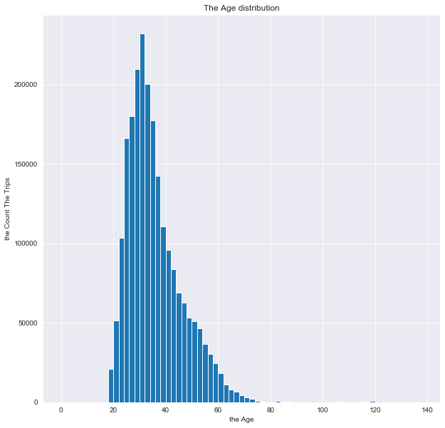

```python
plt.figure(figsize=[10, 10])
df1718_age = df1718_copy.query('Age > 0')
bins = np.arange(0, df1718_age['Age'].max()+2, 2)
plt.hist(data = df1718_age, x = 'Age', bins = bins)
plt.title("The Age distribution")
plt.xlabel('the Age')
plt.ylabel('the Count The Trips');
```

```python
df_outliers_age_100 = df1718_copy[(df1718_copy.Age > 100)]
```

```python
df_outliers_age_100.Age.value_counts()
```

```
118    632
107    262
115    218
116    173
117    171
130     23
104     18
114     12
106     12
110      7
137      5
109      4
129      3
131      2
112      2
Name: Age, dtype: int64
```

```python
# We separate the  ages(age <=100)
df_valid = df1718_copy[(df1718_copy.Age <= 100)]
```

```python
# If at any age he has a mistake columns 'member_birth_year' and 'Age' to 0
df_outliers_age_100.member_birth_year = 0
df_outliers_age_100.Age = 0
```

```python
df_outliers_age_100.head()
```

|  | duration_sec | start_time | end_time | start_station_id | start_station_name | start_station_latitude | start_station_longitude | end_station_id | end_station_name | end_station_latitude | end_station_longitude | bike_id | user_type | member_birth_year | member_gender | Age | duration_mins |
| --- | --- | --- | --- | --- | --- | --- | --- | --- | --- | --- | --- | --- | --- | --- | --- | --- | --- |
| 287 | 581 | 2017-12-31 18:10:46.556 | 2017-12-31 18:20:28.352 | 274 | Oregon St at Adeline St | 37.86 | -122.27 | 173 | Shattuck Ave at 55th Ave | 37.84 | -122.26 | 3050 | Subscriber | 0 | Male | 0 | 9.68 |
| 1751 | 370 | 2017-12-30 17:17:54.969 | 2017-12-30 17:24:05.481 | 207 | Broadway at Coronado Ave | 37.84 | -122.25 | 173 | Shattuck Ave at 55th Ave | 37.84 | -122.26 | 456 | Subscriber | 0 | Male | 0 | 6.17 |
| 3119 | 457 | 2017-12-29 18:24:08.722 | 2017-12-29 18:31:46.008 | 207 | Broadway at Coronado Ave | 37.84 | -122.25 | 173 | Shattuck Ave at 55th Ave | 37.84 | -122.26 | 1238 | Subscriber | 0 | Male | 0 | 7.62 |
| 3259 | 613 | 2017-12-29 17:20:22.096 | 2017-12-29 17:30:35.527 | 173 | Shattuck Ave at 55th Ave | 37.84 | -122.26 | 207 | Broadway at Coronado Ave | 37.84 | -122.25 | 1238 | Subscriber | 0 | Male | 0 | 10.22 |
| 5246 | 271 | 2017-12-28 16:48:41.310 | 2017-12-28 16:53:12.645 | 158 | Shattuck Ave at Telegraph Ave | 37.83 | -122.26 | 173 | Shattuck Ave at 55th Ave | 37.84 | -122.26 | 173 | Subscriber | 0 | Male | 0 | 4.52 |

```python
#  new dataframe
df_valid = df_valid.append(df_outliers_age_100, sort=False, ignore_index=True)
```

```python
df1718_copytow = df_valid.copy()
```

#### We corrected the age and calendar year values and now we divide the age values into age groups ، to make further bivariate or multivariate analysis more comfortable

```python
df1718_copytow['Gage'] = pd.cut(df1718_copytow.Age, [0,24,34,44,54,64,74,84,94,100], labels =['15-24', '25-34','35-44', '45-54','55-64', '65-74','75-84', '85-94','95-100'])
```

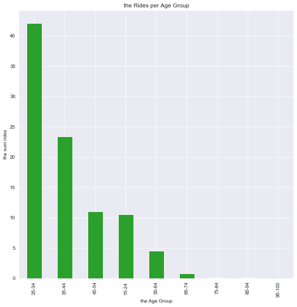

```python
plt.figure(figsize=[10, 10])
x=len(df1718_copytow)
(df1718_copytow.Gage.value_counts()/x*100).plot.bar(color = sb.color_palette()[2]);
plt.title("the Rides per Age Group")
plt.ylabel('the sum rides')
plt.xlabel('the Age Group');
```

## Of the features you investigated, were there any unusual distributions? Did you perform any operations on the data to tidy, adjust, or change the form of the data? If so, why did you do this?

initially we go to go for the age rather year of birth . so including and computing this segment has been essential. Likewise, I investigated the estimations of the segment 'Age' and chose to set each an incentive over 100 years to 0. furthermore, eliminate exceptions in age rather than mean. also, we make new section 'Gage' and put it into the age esteem: start with 15 to 24 years, till 95 to long term.

# Exploration

analyze which user group by age and gender

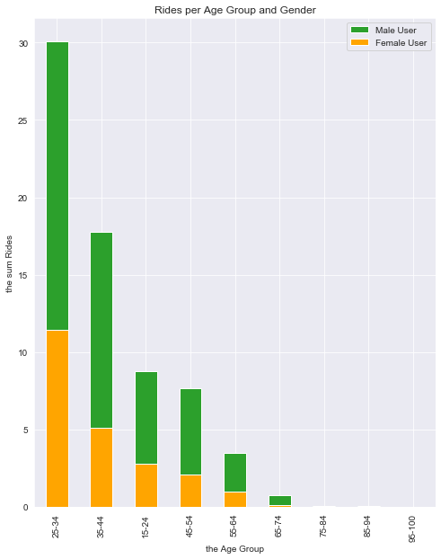

```python
df2_male = df1718_copytow[(df1718_copytow.member_gender == "Male")]
df2_female = df1718_copytow[(df1718_copytow.member_gender == "Female")]
x=len(df1718_copytow)
q=len(df1718_copytow)
plt.figure(figsize=[8, 10])
#///////////////////////////////////////////////////////////////////////
(df2_male.Gage.value_counts() / x*100).plot.bar(color = sb.color_palette()[2], label='Male User');
(df2_female.Gage.value_counts() / q*100).plot.bar(color = 'orange', label='Female User');
plt.legend(loc='upper right')
plt.title("Rides per Age Group and Gender")
plt.ylabel('the sum Rides')
plt.xlabel('the Age Group');
```

```python
df2_without_age_nan = df1718_copytow[(df1718_copytow.Age.notnull()) &((df1718_copytow.member_gender == "Male") |(df1718_copytow.member_gender == "Female"))]
df2_without_age_nan = df1718_copytow[(df1718_copytow.Age.notnull()) &((df1718_copytow.member_gender == "Male") |(df1718_copytow.member_gender == "Female"))]
```

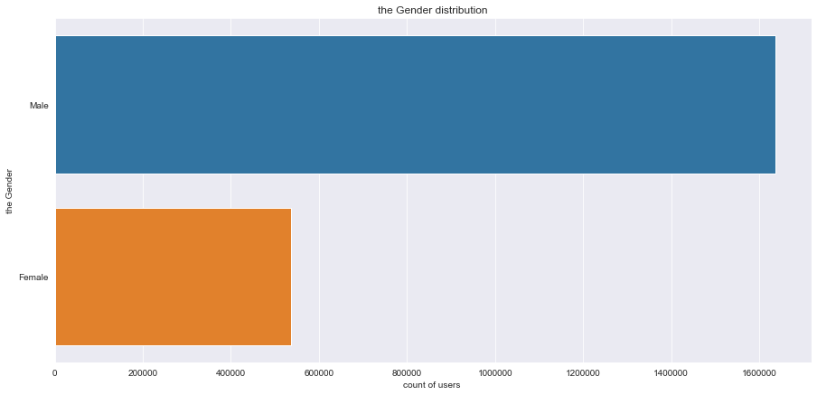

```python
plt.figure(figsize=[15, 7])
sb.countplot(data = df2_without_age_nan, y = 'member_gender')
plt.title('the Gender distribution')
plt.xlabel('count of users ')
plt.ylabel('the Gender');
```

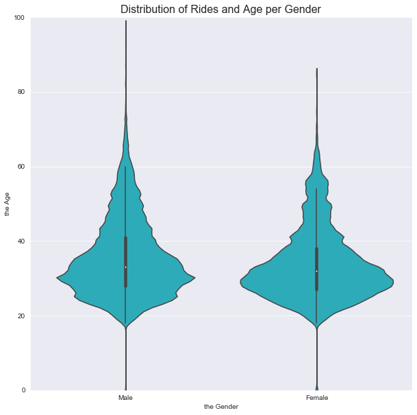

```python
plt.figure(figsize=[10, 10])
sb.violinplot(data = df2_without_age_nan, x = 'member_gender', y = 'Age', color = sb.color_palette()[9])
plt.title("Distribution of Rides and Age per Gender", fontsize=16)
plt.ylabel("the Age")
plt.xlabel("the Gender")
plt.ylim([0,100]);
```

the male have higher ages , A group of female groups, dense at the age of 30

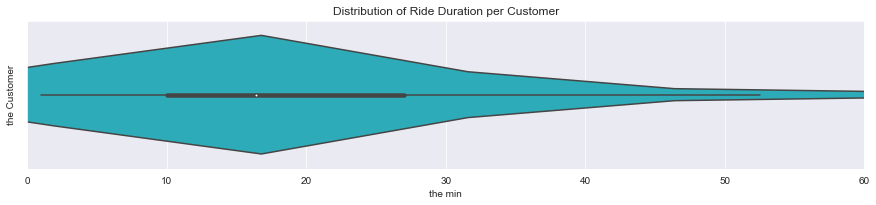

```python
plt.figure(figsize=[15, 6])
df2_customer = df1718_copytow[(df1718_copytow.user_type == "Customer")]
plt.subplot(2, 1, 1)
sb.violinplot(x='duration_mins', data = df2_customer, color = sb.color_palette()[9], label ="Customer")
plt.title("Distribution of Ride Duration per Customer")
plt.xlabel("the min")
plt.ylabel("the Customer")
plt.xlim(0,60);
```

[figure not shown]

```python
plt.figure(figsize=[15, 6])
df2_subscriber = df1718_copytow[(df1718_copytow.user_type == "Subscriber")]
plt.subplot(2, 1, 1)
sb.violinplot(x='duration_mins', data = df2_customer, color = sb.color_palette()[9], label ="Subscriber")
plt.title("Distribution of Ride Duration per Subscriber")
plt.xlabel("the min")
plt.ylabel("the Subscriber")
plt.xlim(0,60);
```

```python
Sno_outliers = df2_subscriber[(df2_subscriber.duration_sec <= 14400)]
```

```python
# remove outlying
print(str(len(df2_subscriber) - len(Sno_outliers)) )
```

```
2139
```

# Talk about some of the relationships you observed in this part of the investigation. How did the feature(s) of interest vary with other features in the dataset?

generally younger than male users

# Did you observe any interesting relationships between the other features (not the main feature(s) of interest)?

# Exploration

In this step we will explore how it differs number of rides and the duration differs number of subscribers of gender and age group.

```python
# male & female
Skeep_male_female = Sno_outliers[(Sno_outliers.member_gender != "Other")]
```

```python
Skeep_male_female.member_gender.value_counts()
```

```
Male      1467829
Female     457350
Name: member_gender, dtype: int64
```

```python
Srides= Skeep_male_female.groupby(['member_gender', 'Gage']).size()
Srides = Srides.reset_index(name = 'count')
Srides = Srides.pivot(index = 'Gage', columns = 'member_gender', values = 'count')
Srides.sample(3)
```

| member_gender Gage | Female | Male |
| --- | --- | --- |
| 15-24 | 50555 | 157537 |
| 95-100 | 0 | 88 |
| 45-54 | 44085 | 191880 |

```python
Sduration = Skeep_male_female.groupby(['member_gender', 'Gage'])['duration_sec'].agg('sum')
Sduration = Sduration
Sduration = Sduration.reset_index(name = 'duration_min')
Sduration = Sduration.pivot(index = 'Gage', columns = 'member_gender', values = 'duration_min')
Sduration.sample(3)
```

| member_gender Gage | Female | Male |
| --- | --- | --- |
| 55-64 | 17512649.00 | 54315721.00 |
| 95-100 | nan | 48124.00 |
| 75-84 | 193439.00 | 1184833.00 |

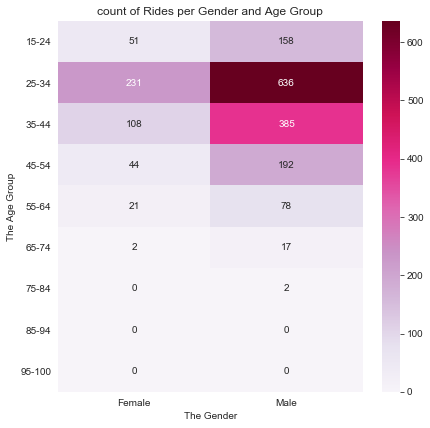

```python
plt.figure(figsize = [15, 15])
plt.subplot(2, 2, 1)
sb.heatmap(Srides/1000, annot = True, fmt =  '.0f',  cmap = 'PuRd')
plt.title("count of Rides per Gender and Age Group")
plt.ylabel("The Age Group")
plt.xlabel("The Gender")
plt.yticks(rotation=360);
```

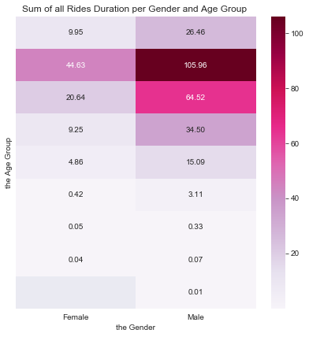

```python
plt.figure(figsize = [15, 15])
plt.subplot(2, 2, 2)
sb.heatmap(Sduration/60/60/1000, annot = True, fmt =  '.2f',  cmap = 'PuRd', yticklabels=False)
plt.title("Sum of all Rides Duration per Gender and Age Group ")
plt.ylabel("the Age Group")
plt.xlabel("the Gender");
```

```python
SDS = Sduration / Srides
```

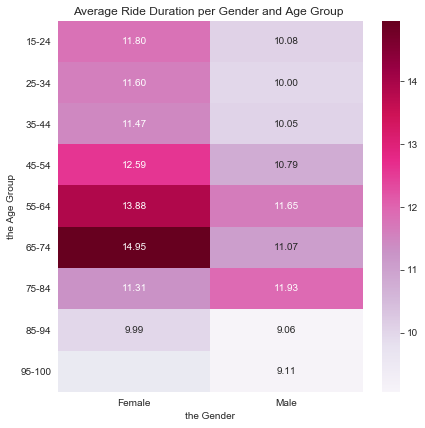

```python
plt.figure(figsize = [15, 15])
plt.subplot(2, 2, 3)
sb.heatmap(SDS/60, annot = True, fmt =  '.2f',  cmap = 'PuRd');
plt.title("Average Ride Duration per Gender and Age Group ")
plt.ylabel("the Age Group")
plt.xlabel("the Gender")
plt.yticks(rotation=360);
```

## Talk about some of the relationships you observed in this part of the investigation. Were there features that strengthened each other in terms of looking at your feature(s) of interest?

I saw that the use in terms of number of rides and the duration do not diverge a lot number of gender and age group . That implies, the group with most rides additionally has the most noteworthyride duration.

I will discuss the initial two heatmaps show, which sub segments are utilizing FordGoBike widely and which are definitely not. the hazier the colorization, the more significant the fragment and the lighter the colorizationt the less important the segment

if we see heatmaps, we can ident which segment can be marketed.

the old we have group from 45 to 54 years , dont uesing blkes a lot

## Were there any interesting or surprising interactions between features?

```python
df1718_copytow.to_csv("fordgobike_explain.csv", header=True, index=False)
```